# Demo_ggplot 2_geom_point

Jessica Tuleassi

2026-04-03

## About ggplot2

ggplot2 is a system for declaratively creating graphics, based on [The Grammar of Graphics](https://link.springer.com/book/10.1007/0-387-28695-0). You provide the data, tell ggplot2 how to map variables to aesthetics, what graphical primitives to use, and it takes care of the details.

It’s hard to succinctly describe how ggplot2 works because it embodies a deep philosophy of visualisation. However, in most cases you start with ggplot(), supply a dataset and aesthetic mapping (with aes()). You then add on layers (like geom_point() or geom_histogram()), scales (like scale_colour_brewer()), faceting specifications (like facet_wrap()) and coordinate systems (like coord_flip()).

Ggplot2 is embedded in the tidyverse package. You can also separately install it using install.packages(“ggplot2”)

### Themes in ggplot

ggplot2 comes with a number of built-in themes. The most important is theme_grey(), the signature ggplot2 theme with a light grey background and white gridlines.

theme_bw(): a variation on theme_grey() that uses a white background and thin grey grid lines.

theme_linedraw(): a theme with only black lines of various widths on white backgrounds, reminiscent of a line drawing.

theme_light(): similar to theme_linedraw() but with light grey lines and axes, to direct more attention towards the data.

theme_dark(): the dark cousin of theme_light(), with similar line sizes but a dark background. Useful to make thin coloured lines pop out.

theme_minimal(): a minimalistic theme with no background annotations.

theme_classic(): a classic-looking theme, with x and y axis lines and no gridlines.

theme_void(): a completely empty theme.

```r
# install packages

if (!require("tidyverse")) install.packages("tidyverse")
if (!require("patchwork")) install.packages("patchwork")
if (!require("ggrepel")) install.packages("ggrepel")
```

## Contraception Dataset

The data in contraception.csv were collected from several sources (e.g., World Bank). The variables are:

*country: Country name

*region: Region of the world

*contraceptive: Percentage of women who are practicing, or whose sexual partners are practicing, any form of contraception. It is usually measured for women ages 15–49 who are married or in union.

*educ_female: Average number of years of formal education (schooling) for females

*gni: Categorical measure of the economy indicating if the country has a low or high gross national income

```r
######import data######

contraception = read_csv("https://raw.githubusercontent.com/zief0002/symmetrical-fiesta/main/data/contraception.csv")

# View data
contraception
```

```
## # A tibble: 97 × 5
##    country                region                 contraceptive educ_female gni
##    <chr>                  <chr>                          <dbl>       <dbl> <chr>
##  1 Algeria                Middle East and North…            57         5.9 High
##  2 Austria                Europe and Central As…            66         8.9 High
##  3 Azerbaijan             Europe and Central As…            55        10.5 High
##  4 Bangladesh             South Asia                        62         4.6 Low
##  5 Belgium                Europe and Central As…            67        10.5 High
##  6 Belize                 Latin America and the…            51         9.2 High
##  7 Benin                  Sub-Saharan Africa                16         2   Low
##  8 Bolivia                Latin America and the…            67         8.4 Low
##  9 Bosnia and Herzegovina Europe and Central As…            46         7.2 High
## 10 Botswana               Sub-Saharan Africa                53         8.7 High
## # ℹ 87 more rows
```

```r
# IF you want to see all the variables
#print(contraception, width = Inf)
```

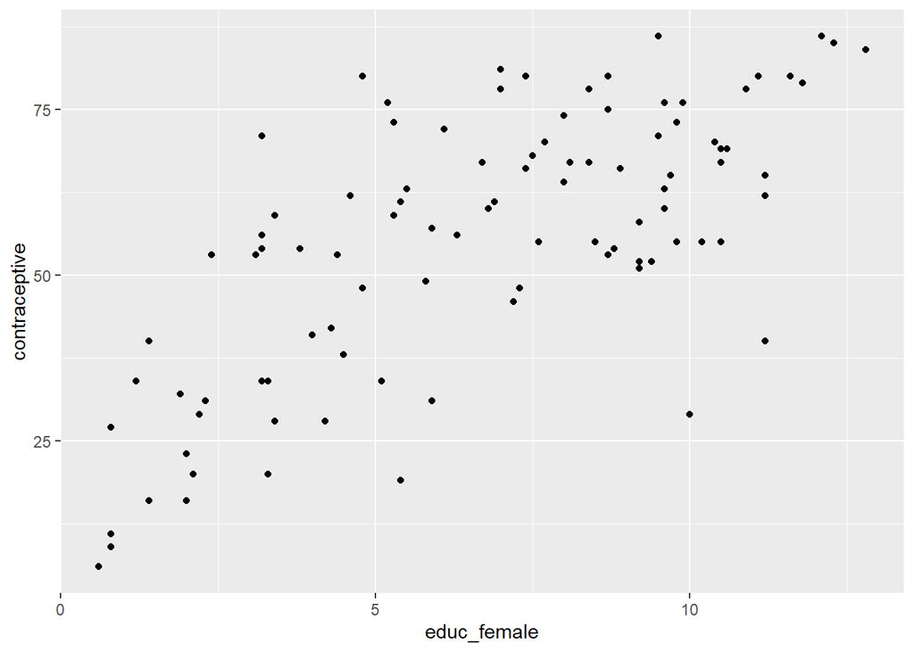

```r
# Geom point

gp <- ggplot(data = contraception, aes(x = educ_female, y = contraceptive)) +
  geom_point()

print(gp)
```

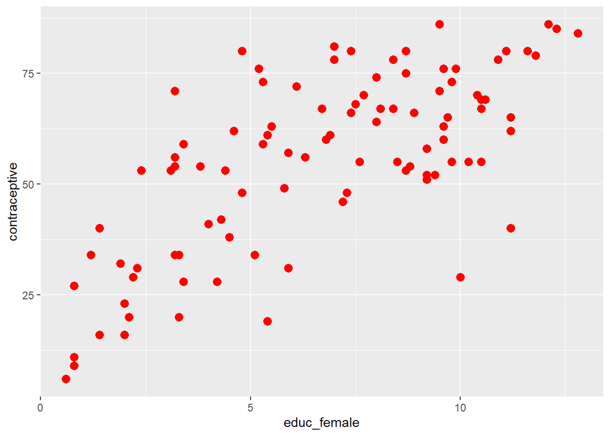

```r
#### add color

gp2 <- ggplot(data = contraception, aes(x = educ_female, y = contraceptive)) + geom_point(colour = "red", size = 3)

print(gp2)
```

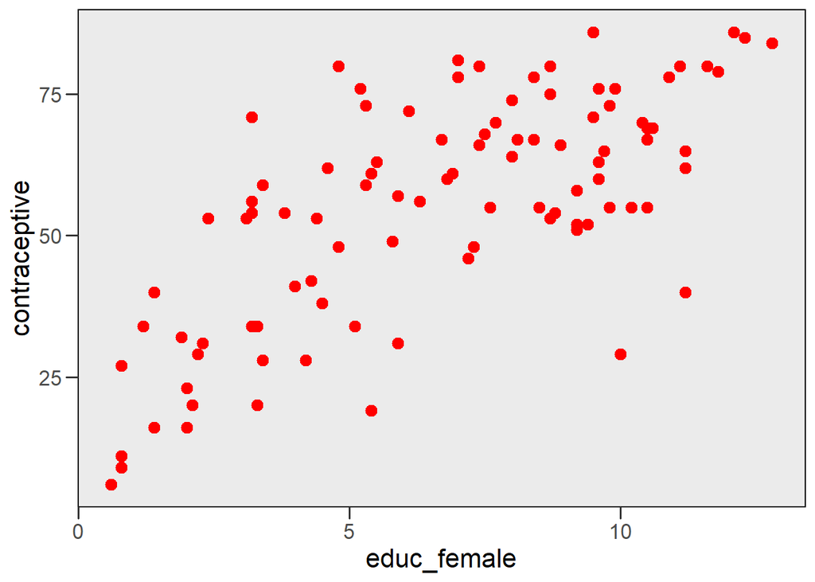

```r
#### Adding themes: theme base
gp3 <- ggplot(data = contraception, aes(x = educ_female, y = contraceptive)) + geom_point(colour = "red", size = 3)+
theme_base()

print(gp3)
```

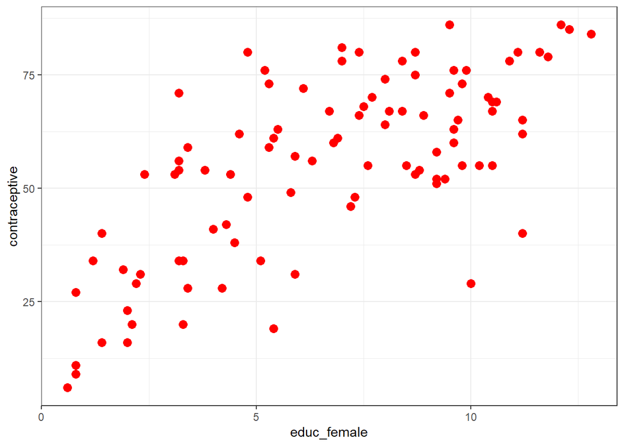

```r
gp4 <- ggplot(data = contraception, aes(x = educ_female, y = contraceptive)) + geom_point(colour = "red", size = 3)+
theme_bw()

print(gp4)
```

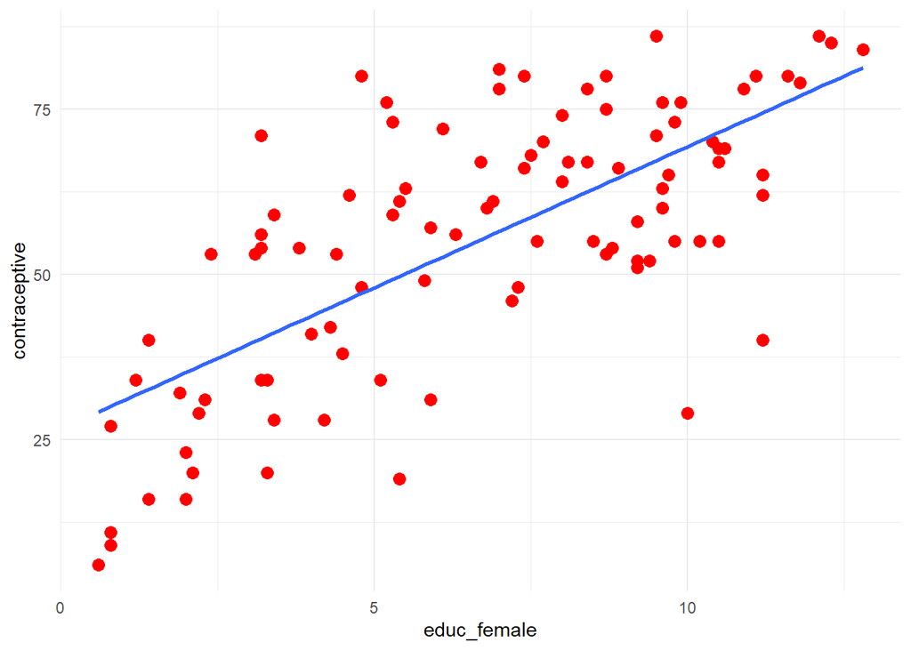

```r
gp5 <- ggplot(data = contraception, aes(x = educ_female, y = contraceptive)) + geom_point(colour = "red", size = 3)+
geom_smooth(method = "lm", se = FALSE)+
theme_minimal()

print(gp5)
```

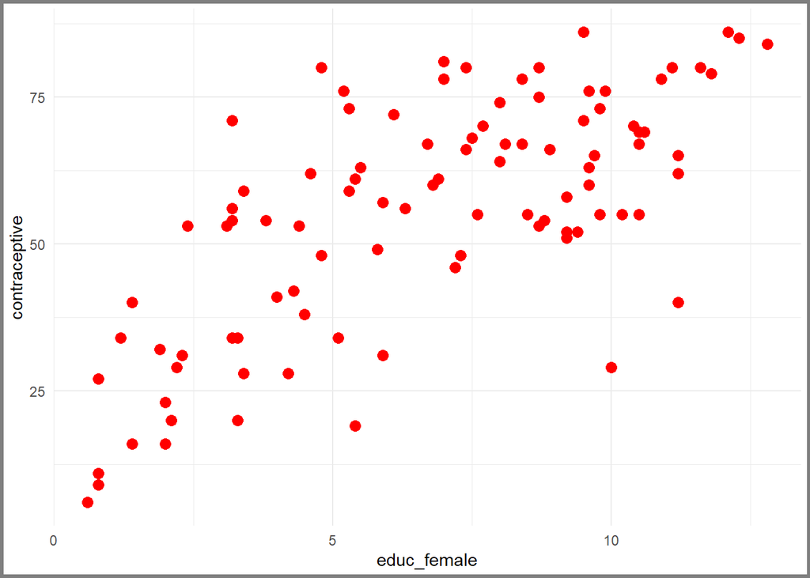

```r
####Plot elements
gp6 <- ggplot(data = contraception, aes(x = educ_female, y = contraceptive)) + geom_point(colour = "red", size = 3)+
theme_minimal()

gp6 + theme(plot.background = element_rect(colour = "grey50", linewidth = 2))
```

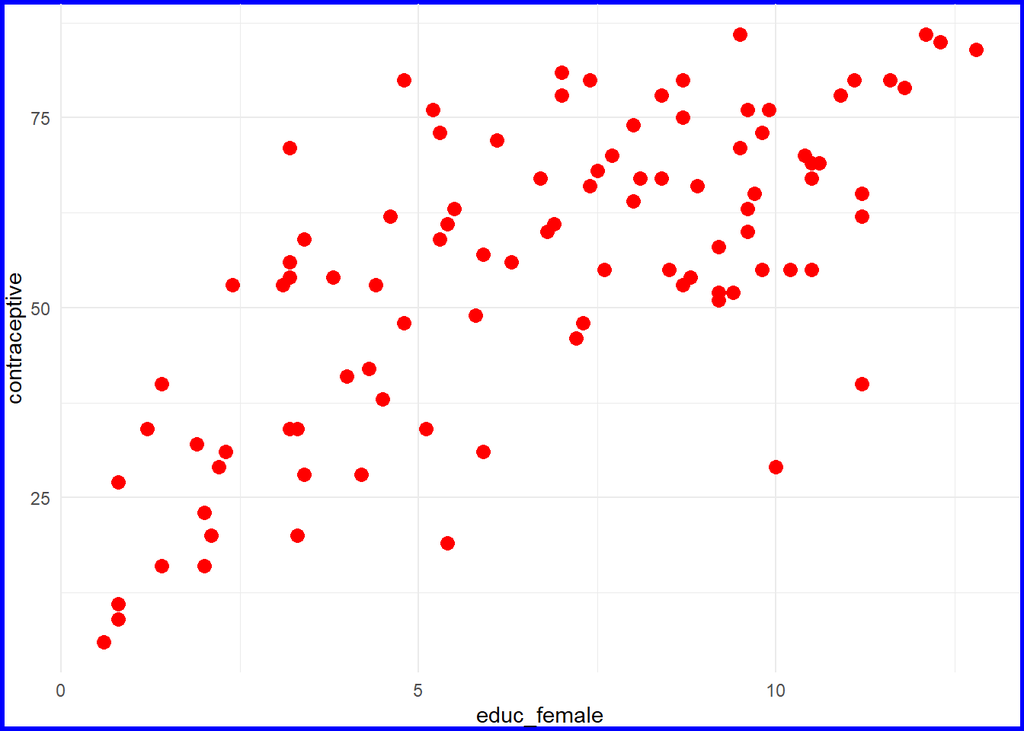

```r
gp6 + theme(
  plot.background = element_rect(colour = "blue", linewidth = 2),
  plot.margin = margin(2, 2, 2, 2)
)
```

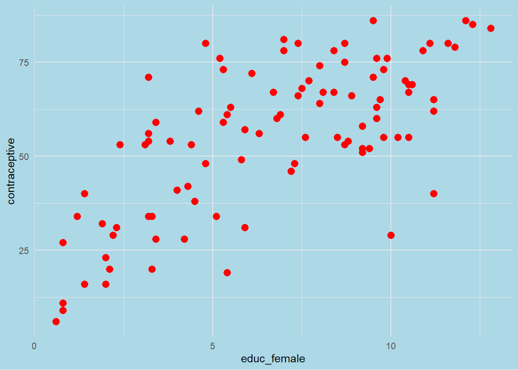

```r
gp6 + theme(plot.background = element_rect(fill = "lightblue"))
```

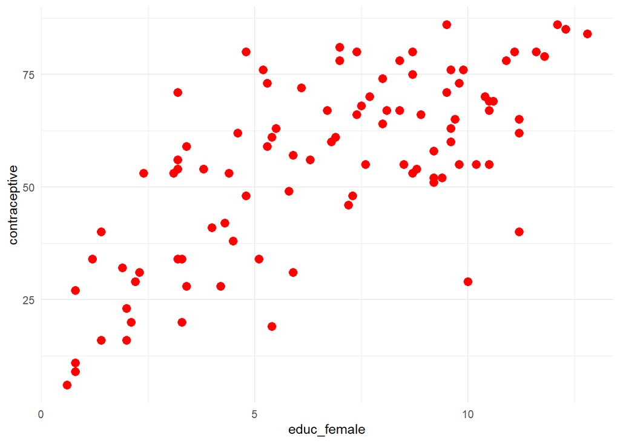

```r
print(gp6)
```

## About Patchwork

The patchwork package in R is an extension of the ggplot2 package, designed to simplify the process of combining multiple plots into a single layout.

### Combining plots

You can combine multiple plots using the + operator.

### Arranging plots

Use the / operator to stack plots on top of each other.

### Nesting Plots

You can nest plots using parentheses. Example: (p1 + p2) / p1

### Adding Titles and Annotations

patchwork allows you to add titles, subtitles, and captions to your combined plots. For example, you can p1 + p2 + plot_annotation(title = ‘My Combined Plot’)

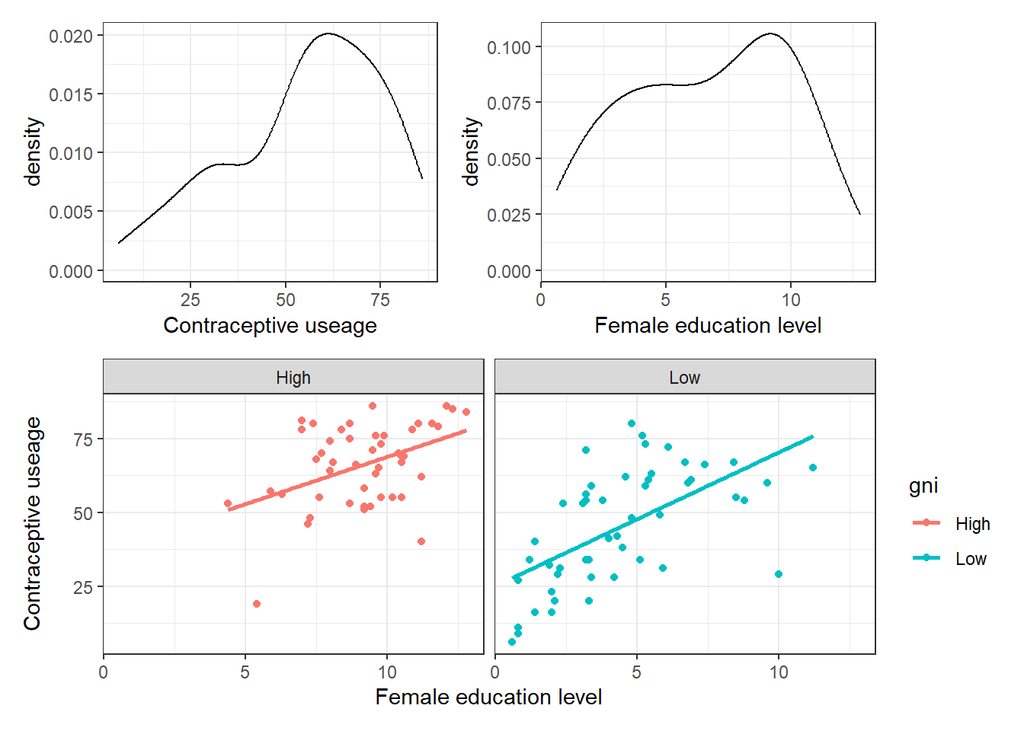

```r
# Create density plot of contraception
p1 = ggplot(data = contraception, aes(x = contraceptive)) +
  geom_density() +
  theme_bw() +
  labs(
    x = "Contraceptive useage"
  )

# Create density plot of female education level
p2 = ggplot(data = contraception, aes(x = educ_female)) +
  geom_density() +
  theme_bw() +
  labs(
    x = "Female education level"
  )


# Condition the relationship on GNI
p3 = ggplot(data = contraception, aes(x = educ_female, y = contraceptive, color = gni)) +
  geom_point() +
  geom_smooth(method = "lm", se = FALSE) +
  theme_bw() +
  labs(
    x = "Female education level",
    y = "Contraceptive useage"
  ) +
  facet_wrap(~gni)

# Layout plots with patchwork
(p1 | p2) / p3
```

## About ggrepel

ggrepel provides geoms for ggplot2 to repel overlapping text labels:

geom_text_repel(): adds text labels to plots while automatically preventing them from overlapping with each other, the data points, or the plot edges

geom_label_repel(): adds text labels to a ggplot2 plot with a boxed background, automatically pushing them away from each other and away from data points to prevent overlaps. It improves readability on crowded plots by drawing lines connecting labels to their corresponding data points.

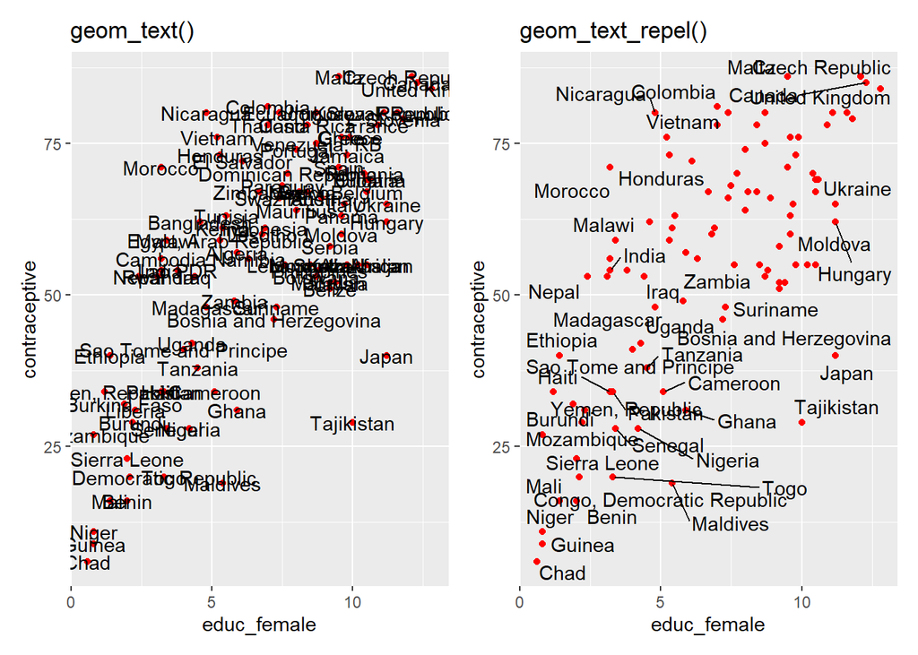

```r
##Let’s compare geom_text() and geom_text_repel():

set.seed(42)

p <- ggplot(contraception, aes(x = educ_female, y = contraceptive, label = country)) +
  geom_point(color = "red")

p1 <- p + geom_text() + labs(title = "geom_text()")

p2 <- p + geom_text_repel() + labs(title = "geom_text_repel()")

p1+p2
```

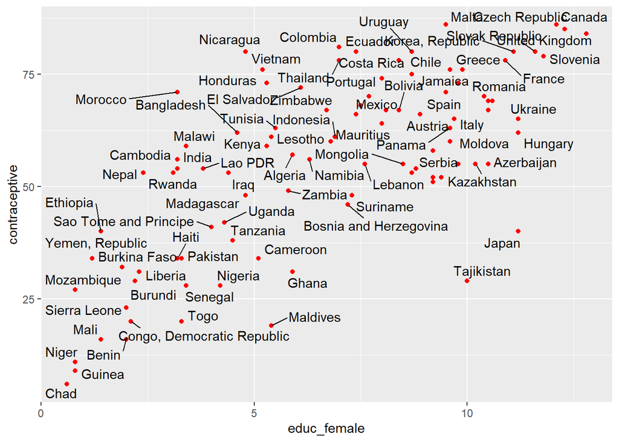

```r
set.seed(42)
gr = ggplot(contraception, aes(x = educ_female, y = contraceptive, label = country),
  size = wt,
  segment.color = NA) +
  geom_point(color = "red") +
  geom_text_repel(point.size = 1)


print(gr)
```

## Exercise

### Question 1

1. In this exercise, you will use find the relationship between gni and contraception.

Use this code: g1 <- ggplot(data = contraception, aes(x = , y = )) + geom_point()

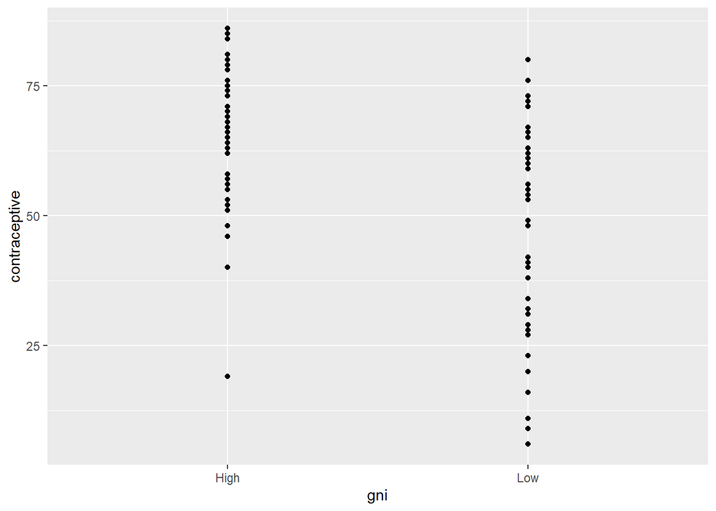

```r
e1 <- ggplot(data = contraception, aes(x = gni, y = contraceptive)) +
  geom_point()

print(e1)
```

2. color the points with any color of your choice

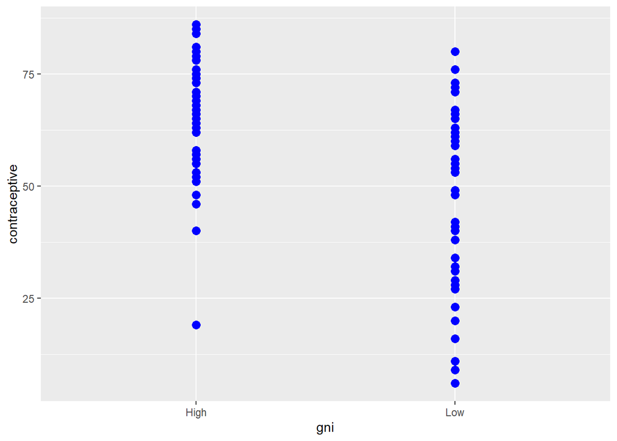

```r
#### add color

e1b <- ggplot(data = contraception, aes(x = gni, y = contraceptive)) + geom_point(colour = "blue", size = 3)

print(e1b)
```

### Question 2

Nest the plot using this cod: (p1 + p2) / p1. Chunk code can be found above

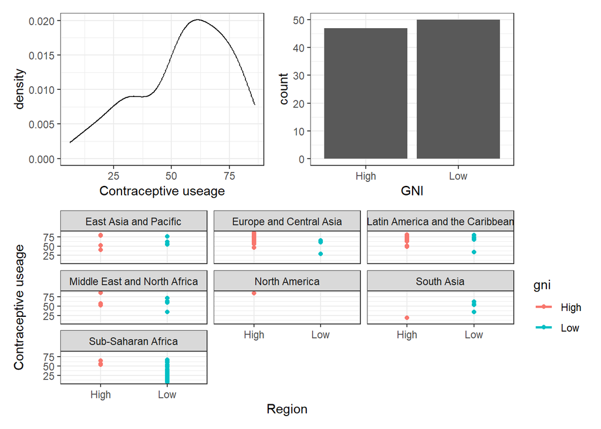

```r
# Create density plot of contraception
e2 = ggplot(data = contraception, aes(x = contraceptive)) +
  geom_density() +
  theme_bw() +
  labs(
    x = "Contraceptive useage"
  )

# Create density plot of female education level
e2a = ggplot(data = contraception, aes(x = gni)) +
  geom_bar() +
  theme_bw() +
  labs(
    x = "GNI"
  )


# Condition the relationship on GNI
e2b = ggplot(data = contraception, aes(x = gni, y = contraceptive, color = gni)) +
  geom_point() +
  geom_smooth(method = "lm", se = FALSE) +
  theme_bw() +
  labs(
    x = "Region",
    y = "Contraceptive useage"
  ) +
  facet_wrap(~region)

# Layout plots with patchwork
(e2 + e2a) / e2b
```

## Notes

You can find inspiration on how to develop your graphs using the [R Graph Galley](https://r-graph-gallery.com/)